# Popularity and Loneliness Study 1 Data Analysis

We use groundhog (https://groundhogr.com/) to manage our packages. Groundhog makes sure that our package versions are consistent with the current date. This way, everyone will be using packages from the same date to prevent any issues related to package versioning in future analyses.

To use groundhog, please: (1) make sure that you have the latest version of R/ RStudio installed; (2) install RTools (3) make sure you are in a new R Session

The R Version used to create this file is: `R version 4.3.0 (2023-04-21 ucrt)`. You can change this out with your own version of R if you are using this template to create your own analysis. If you are reproducing another person’s analysis, please download the version of R used by the previous person to ensure a proper reproduction of the code.

You can identify your version of R by typing `version` into the R Console

You can switch your R version by pressing `Tools` > `Global Options` > `R Version`

```r
library("groundhog")



# put all packages in and call groundhog
pkgs <- c("tidyverse", 'Rmisc', 'tidyverse', 'hablar',
               'patchwork', 'network', 'cowplot', # figures
               'effectsize', 'parameters', 'performance', 'lmerTest', # regression models
               'lsa','interactions', # cosine
               'MuMIn','hrbrthemes', "patchwork",'dplyr'
    )

pkgs_all <- c(pkgs)

# call groundhog. Change out the date for today's date (unless you are running an old analysis)
groundhog.library(pkgs_all, "2025-04-09")
```

```
All requested packages are already attached
```

### Descriptives

| Term | mean_indegree | sd_indegree | median_indegree | min_indegree | max_indegree | n |
| --- | --- | --- | --- | --- | --- | --- |
| Fall 2019 | 2.036782 | 1.430981 | 1 | 1 | 11 | 2610 |
| Spring 2020 | 1.858086 | 1.238931 | 1 | 1 | 10 | 2424 |

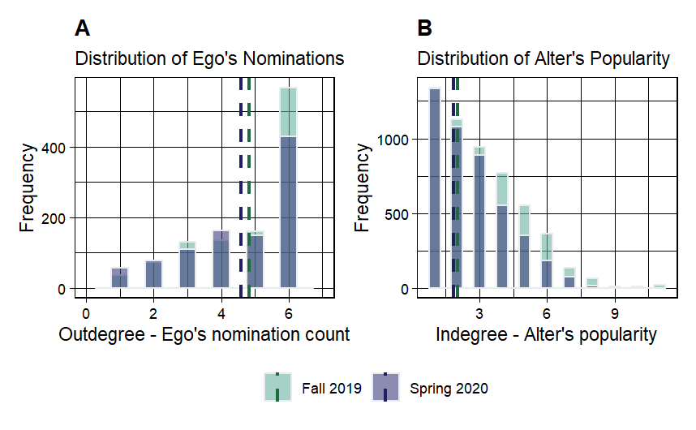

```r
# Display the combined plot
combined_plot
```

### H1 Analysis: Do lonely egos tend to nominate more popular alters?

```r
r.squaredGLMM(r)
```

```
           R2m       R2c
[1,] 0.1313027 0.3148265
```

### Exploratory Analysis

#### whether lonely people were less likely to be nominated in general & reciprocity

```r
indegree_counts <- data %>%
  dplyr::group_by(Term, alter) %>%
  dplyr::summarise(indegree = n(), .groups = "drop")
data <- data %>%
  left_join(indegree_counts, by = c("Term", "alter"))

fit <- lmer(indegree ~ loneAlter + (1|alter), data = data); summary(fit)
```

```
Linear mixed model fit by REML. t-tests use Satterthwaite's  method
 [lmerModLmerTest]
Formula: indegree ~ loneAlter + (1 | alter)
   Data: data

REML criterion at convergence: 13340.7

Scaled residuals:
    Min      1Q  Median      3Q     Max
-7.0455 -0.2886  0.1039  0.4801  2.2761

Random effects:
 Groups   Name        Variance Std.Dev.
 alter    (Intercept) 2.1648   1.4713
 Residual             0.7681   0.8764
Number of obs: 4186, groups:  alter, 1156

Fixed effects:
              Estimate Std. Error         df t value Pr(>|t|)
(Intercept)    2.68550    0.04648 1201.66565  57.778  < 2e-16 ***
loneAlter     -0.11597    0.02715 4142.78450  -4.271 1.99e-05 ***
---
Signif. codes:  0 ‘***’ 0.001 ‘**’ 0.01 ‘*’ 0.05 ‘.’ 0.1 ‘ ’ 1

Correlation of Fixed Effects:
          (Intr)
loneAlter -0.015
```

```r
r.squaredGLMM(fit)
```

```
             R2m       R2c
[1,] 0.004563912 0.7392988
```

```r
confint(fit)
```

```
Computing profile confidence intervals ...
```

```
                 2.5 %     97.5 %
.sig01       1.4052383  1.5398682
.sigma       0.8549294  0.8986077
(Intercept)  2.5935916  2.7769269
loneAlter   -0.1691995 -0.0627575
```

```r
fit <- lmer(recpPer ~ loneEgo + (1|ego), data); summary(fit)
```

```
Linear mixed model fit by REML. t-tests use Satterthwaite's  method
 [lmerModLmerTest]
Formula: recpPer ~ loneEgo + (1 | ego)
   Data: data

REML criterion at convergence: -9512.4

Scaled residuals:
    Min      1Q  Median      3Q     Max
-4.2158 -0.1860 -0.0321  0.2219  7.0075

Random effects:
 Groups   Name        Variance Std.Dev.
 ego      (Intercept) 0.05513  0.2348
 Residual             0.01391  0.1180
Number of obs: 9743, groups:  ego, 1371

Fixed effects:
              Estimate Std. Error         df t value Pr(>|t|)
(Intercept)  2.686e-01  6.489e-03  1.343e+03  41.404  < 2e-16 ***
loneEgo     -1.106e-02  2.684e-03  9.720e+03  -4.121 3.81e-05 ***
---
Signif. codes:  0 ‘***’ 0.001 ‘**’ 0.01 ‘*’ 0.05 ‘.’ 0.1 ‘ ’ 1

Correlation of Fixed Effects:
        (Intr)
loneEgo -0.015
```

```r
r.squaredGLMM(fit)
```

```
             R2m       R2c
[1,] 0.001767679 0.7988382
```

```r
confint(fit)
```

```
Computing profile confidence intervals ...
```

```
                  2.5 %       97.5 %
.sig01       0.22568251  0.244259218
.sigma       0.11618158  0.119760399
(Intercept)  0.25592792  0.281369956
loneEgo     -0.01631752 -0.005798241
```

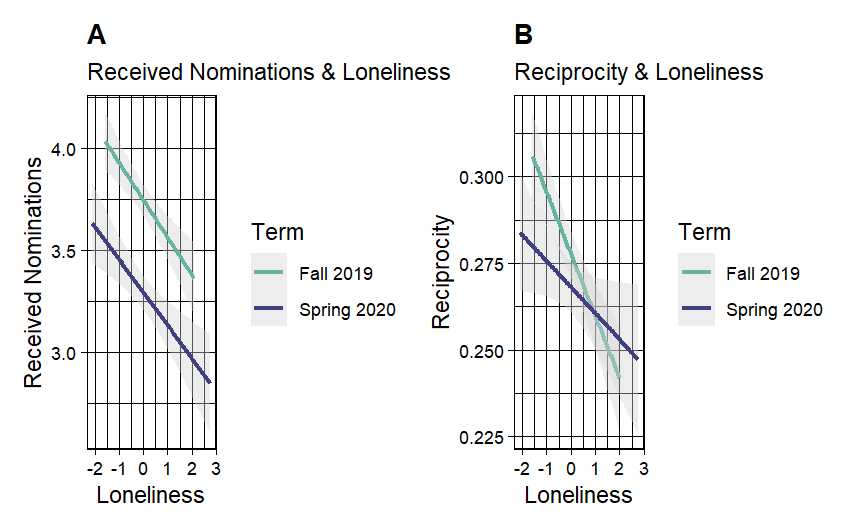

```r
a <- ggplot(data, aes(y = indegree, x = loneAlter, color = Term)) +
    geom_smooth(method = "lm", fill = "lightgray") +
    scale_color_manual(values=c("#69b3a2", "#404080")) +
    theme_linedraw() +
    labs (x = "Loneliness", y = "Received Nominations", title = "A", subtitle = "Received Nominations & Loneliness") + theme(plot.title = element_text(face = "bold"))

b <- ggplot(data, aes(y = recpPer, x = loneEgo, color = Term)) +
  #geom_point(alpha=0.4) +
  geom_smooth(method='lm', fill = "lightgray")+
    theme_linedraw()+
  scale_color_manual(values=c("#69b3a2", "#404080")) +
  labs (x = "Loneliness", y = "Reciprocity", title = "B", subtitle = "Reciprocity & Loneliness") + theme(plot.title = element_text(face = "bold"))
a + b
```

#### whether lonely people are reciprocated more or less by popular people.

| Term | is_popular | mean_saturation | pct_saturated | count |
| --- | --- | --- | --- | --- |
| Fall 2019 | FALSE | 0.8043798 | 50.61728 | 3410 |
| Fall 2019 | TRUE | 0.8936975 | 69.32773 | 1906 |
| Spring 2020 | FALSE | 0.7690100 | 44.04591 | 2413 |
| Spring 2020 | TRUE | 0.8424908 | 55.58608 | 2091 |

#### whether popular people were more likely to be nominated by lonely people in earlier nominations compared to later ones

```r
confint(r)
```

```
Computing profile confidence intervals ...
```

```
                    2.5 %       97.5 %
.sig01        0.247673724  0.277993922
.sigma        0.327669824  0.340505367
(Intercept)   1.342094098  1.391057741
rank         -0.057644128 -0.046529214
loneEgo      -0.026433239  0.016077320
rank:loneEgo -0.005426868  0.005615999
```